#**Verification of Central Limit Theorem**  
##*Example: Class Scores*

###**Central Limit Theorem**  
**Definition**:The central limit theorem states that if you have a population with mean μ and standard deviation σ and take sufficiently large random samples from the population, then the distribution of the sample means will be approximately normally distributed. This will hold true regardless of whether the source population is normal or skewed, provided the sample size is sufficiently large (usually n > 30).  
If the population is normal, then the theorem holds true even for samples smaller than 30. In fact, this also holds true even if the population is binomial, provided that min(np, n(3-p))> 5, where n is the sample size and p is the probability of success in the population. This means that we can use the normal probability model to quantify uncertainty when making inferences about a population mean based on the sample mean.

**Example:** Consider the following set of class scores.

| sn | id | name | score |
| --- | --- | --- | --- |
| 1 | 2017A1PS0607G | GANDHI RAJAT PARAGBHAI . | 20 |
| 2 | 2017A7PS0068G | ABHINAV JAIN . | 14 |
| 3 | 2017B1A10044G | ADITYAVIKRAM PANDEY . | 21 |
| 4 | 2017B1A40819G | V PRIYAL . | 26 |
| 5 | 2017B1A40848G | UTKARSH SINGH . | 22 |
| 6 | 2017B2A30329G | SURAJ GUPTA . | 24 |
| 7 | 2017B2A40437G | PRANAV MEHTA . | 24 |
| 8 | 2017B4A70035G | JAUHAR DHRUV AJOY . | 25 |
| 9 | 2017B5A30005G | ANUBHAV AHLAWAT . | 23 |
| 10 | 2018A1PS0017G | ARNAV SHIVAKUMAR . | 28 |
| 11 | 2018A1PS0066G | NAMAN L SHAH . | 26 |
| 12 | 2018A1PS0321G | YASH JOSHI . | 27 |
| 13 | 2018A1PS0379G | ISHAAN SHARMA . | 28 |
| 14 | 2018A1PS0385G | NISHANT HINGE . | 24 |
| 15 | 2018A1PS0438G | SHLOK ANAND VORA . | 25 |
| 16 | 2018A1PS0657G | MANLEEN KAUR GUJRAL . | 26 |
| 17 | 2018A1PS0698G | ARYAN OCHANI . | 28 |
| 18 | 2018A1PS0967G | DEEPSHIKHA TEWARI . | 28 |
| 19 | 2018A3PS0450G | RONAK SONI . | 26 |
| 20 | 2018A3PS0458G | YUGANSH DAVE . | 27 |
| 21 | 2018A3PS0576G | VEDANSH DAYAL . | 29 |
| 22 | 2018A4PS0050G | SIDDHANT SUNIL PAREKH . | 26 |
| 23 | 2018A4PS0632G | SAWANE MOHIT MANISH . | 26 |
| 24 | 2018A4PS0855G | ADITYA ARYAN . | 25 |
| 25 | 2018A7PS0123G | ROHAN AGARWAL . | 21 |
| 26 | 2018A7PS0148G | MEGH K PATEL . | 21 |
| 27 | 2018A7PS0174G | PARV BUDHIRAJA . | 25 |
| 28 | 2018A7PS0182G | ARJUN BAJPAI . | 22 |
| 29 | 2018A7PS0205G | DIVYAM BANKIMKUMAR SHAH . | 26 |
| 30 | 2018A7PS0229G | PIMPARKAR PARTH AJAY . | 28 |

[output cut: 73 more lines]

| mean | sd |
| --- | --- |
| 24.24 | 4.17 |

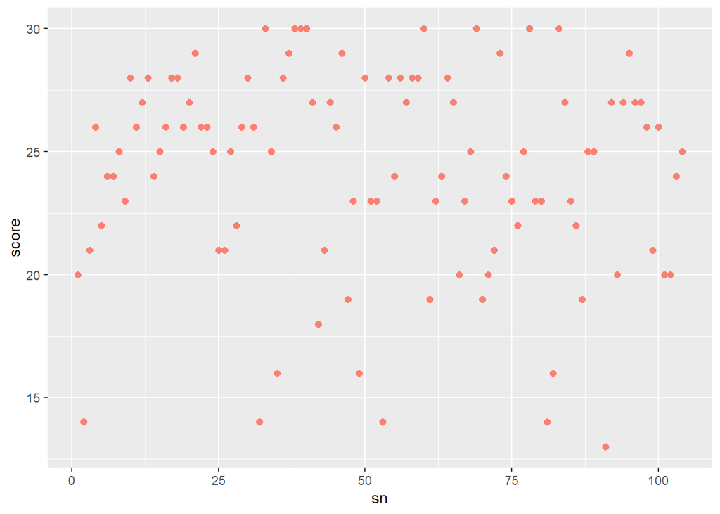

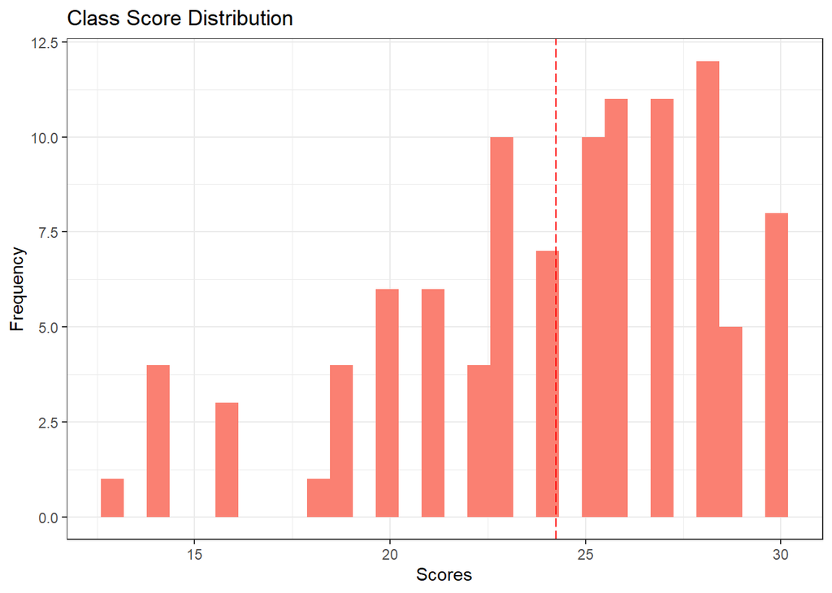

**Next**  
We take 1000 samples of size 30 students each and note their mean and standard deviation

```
## [[1]]
##  [1] 30 20 22 26 27 28 26 26 30 29 26 25 20 16 30 28 26 26 27 28 27 28 16 14 22
## [26] 24 25 29 27 23
```

```
## [[1]]
##  [1] 26 14 26 28 28 23 27 23 25 23 29 30 25 29 28 30 27 30 25 23 26 24 28 28 30
## [26] 28 23 22 27 25
```

```
## [[1]]
##  [1] 23 19 14 20 27 20 28 13 28 23 26 28 16 23 26 21 28 22 19 27 22 23 14 30 20
## [26] 14 20 27 27 25
```

```
## [[1]]
##  [1] 26 26 20 20 23 28 24 24 22 13 29 29 14 25 27 29 27 30 29 23 30 26 20 30 24
## [26] 28 23 30 25 16
```

```
## [[1]]
##  [1] 23 27 27 27 29 29 26 21 22 29 26 20 25 28 27 27 13 28 24 16 26 28 24 28 24
## [26] 30 28 29 14 27
```

| sample_no | sample_mean | sample_sd |
| --- | --- | --- |
| 1 | 25.03 | 4.24 |
| 2 | 26.00 | 3.33 |
| 3 | 24.67 | 3.74 |
| 4 | 24.23 | 3.14 |
| 5 | 24.00 | 3.63 |
| 6 | 23.33 | 4.37 |
| 7 | 24.10 | 4.61 |
| 8 | 24.27 | 3.74 |
| 9 | 23.80 | 4.02 |
| 10 | 22.43 | 4.88 |
| 11 | 24.27 | 4.21 |
| 12 | 24.27 | 4.06 |
| 13 | 23.27 | 5.09 |
| 14 | 24.97 | 3.66 |
| 15 | 24.50 | 4.58 |
| 16 | 25.13 | 3.77 |
| 17 | 24.87 | 3.79 |
| 18 | 25.13 | 3.66 |
| 19 | 23.27 | 4.32 |
| 20 | 24.73 | 3.67 |
| 21 | 24.20 | 4.22 |
| 22 | 24.13 | 3.98 |
| 23 | 24.80 | 4.34 |
| 24 | 24.20 | 4.30 |
| 25 | 23.70 | 4.35 |
| 26 | 24.70 | 4.47 |
| 27 | 24.07 | 3.96 |
| 28 | 23.10 | 4.46 |
| 29 | 25.27 | 3.43 |
| 30 | 24.03 | 4.51 |

[output cut: 970 more lines]

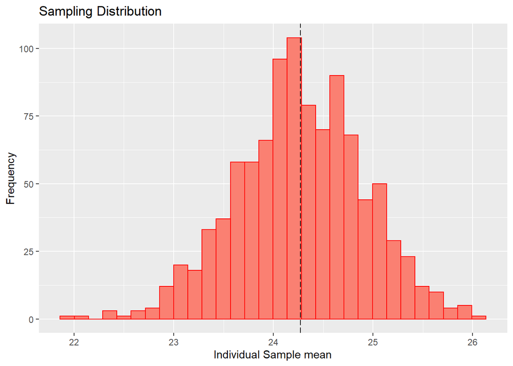

Comparing with the population

| Population_mean | Population_sd | Sampling_dist_mean | Sampling_dist_sd |
| --- | --- | --- | --- |
| 24.24 | 4.17 | 24.27 | 0.64 |

**To explore the relation between scores and parental income**

```
##     x s1 s2 s3 s4
## 1   1 30 26 27 24
## 2   2 20 14 26 25
## 3   3 22 26 30 29
## 4   4 26 28 25 28
## 5   5 27 28 23 23
## 6   6 28 23 22 29
## 7   7 26 27 25 26
## 8   8 26 23 13 20
## 9   9 30 25 27 26
## 10 10 29 23 27 30
## 11 11 26 29 20 24
## 12 12 25 30 20 19
## 13 13 20 25 24 19
## 14 14 16 29 26 23
```

[output cut: 16 more lines]

[figure not shown]